# Taller 9

Métodos Computacionales para Políticas Públicas - URosario

**Entrega: viernes 28-oct-2016 11:59 PM**

**[David Valles]**  
[david.valles@urosario.edu.co]

## Instrucciones:

- Guarde una copia de este *Jupyter Notebook* en su computador, idealmente en una carpeta destinada al material del curso.
- Modifique el nombre del archivo del *notebook*, agregando al final un guión inferior y su nombre y apellido, separados estos últimos por otro guión inferior. Por ejemplo, mi *notebook* se llamaría: mcpp_taller9_santiago_matallana
- Marque el *notebook* con su nombre y e-mail en el bloque verde arriba. Reemplace el texto "[Su nombre acá]" con su nombre y apellido. Similar para su e-mail.
- Desarrolle la totalidad del taller sobre este *notebook*, insertando las celdas que sea necesario debajo de cada pregunta. Haga buen uso de las celdas para código y de las celdas tipo *markdown* según el caso.
- Recuerde salvar periódicamente sus avances.
- Cuando termine el taller:
  1. Descárguelo en PDF. Si tiene algún problema con la conversión, descárguelo en HTML.
  2. Suba todos los archivos a su repositorio en GitHub, en una carpeta destinada exclusivamente para este taller, antes de la fecha y hora límites.

NLTK Book (http://www.nltk.org/book/), Exercises:

- Chapter 1: 22, 26, 28
- Chapter 2: 2, 4, 11

```python
import nltk
```

```python
dler = nltk.downloader.Downloader()
dler._update_index()
dler._status_cache['panlex_lite'] = 'installed' # Trick the index to treat panlex_lite as it's already installed.
dler.download('all')
```

```
True
```

```python
from nltk.book import *
```

```
*** Introductory Examples for the NLTK Book ***
Loading text1, ..., text9 and sent1, ..., sent9
Type the name of the text or sentence to view it.
Type: 'texts()' or 'sents()' to list the materials.
text1: Moby Dick by Herman Melville 1851
text2: Sense and Sensibility by Jane Austen 1811
text3: The Book of Genesis
text4: Inaugural Address Corpus
text5: Chat Corpus
text6: Monty Python and the Holy Grail
text7: Wall Street Journal
text8: Personals Corpus
text9: The Man Who Was Thursday by G . K . Chesterton 1908
```

### Chapter 1

22.Find all the four-letter words in the Chat Corpus (text5). With the help of a frequency distribution (FreqDist), show these words in decreasing order of frequency.

```python
words_4 = [w for w in (text5) if len(w) == 4]
fdist=FreqDist(words_4)
fdist.most_common()
```

```
[('JOIN', 1021),
 ('PART', 1016),
 ('that', 274),
 ('what', 183),
 ('here', 181),
 ('....', 170),
 ('have', 164),
 ('like', 156),
 ('with', 152),
 ('chat', 142),
 ('your', 137),
 ('good', 130),
 ('just', 125),
 ('lmao', 107),
 ('know', 103),
 ('room', 98),
 ('from', 92),
 ('this', 86),
 ('well', 81),
 ('back', 78),
 ('hiya', 78),
 ('they', 77),
 ('yeah', 75),
 ('dont', 75),
 ('want', 71),
 ('love', 60),
 ('some', 58),
 ('guys', 58),
 ('been', 57),
 ('talk', 56),
 ('nice', 52),
 ('time', 50),
 ('when', 48),
 ('make', 44),
 ('haha', 44),
 ('need', 43),
 ('girl', 43),
 ('U122', 42),
 ('MODE', 41),
 ('much', 40),
```

[output cut: 946 more lines]

```
 ('Mono', 1),
 ('ribs', 1),
 ('AKST', 1),
 ('star', 1),
 ("yw's", 1),
 ('twit', 1),
 ('Kent', 1),
 ('Save', 1),
 ('laid', 1),
 ('2:55', 1),
 ('yesh', 1),
 ('rape', 1),
 ('kina', 1),
 ('Oops', 1),
 ...]
```

26.What does the following Python code do? sum(len(w) for w in text1) Can you use it to work out the average word length of a text?

```python
#Suma las longitudes de cada palabra en el texto 1.
sum([len(w) for w in text1]) / len(text1)
```

```
3.830411128023649
```

28.Define a function percent(word, text) that calculates how often a given word occurs in a text, and expresses the result as a percentage.

```python
def percent(word, text):
    return 100 * text.count(word) / len(text)
print (str(percent('monstrous', text1)) + '%')
```

```
0.003834076505162584%
```

### Chapter 2

2.Use the corpus module to explore austen-persuasion.txt. How many word tokens does this book have? How many word types?

```python
nltk.corpus.gutenberg.fileids()
```

```
['austen-emma.txt',
 'austen-persuasion.txt',
 'austen-sense.txt',
 'bible-kjv.txt',
 'blake-poems.txt',
 'bryant-stories.txt',
 'burgess-busterbrown.txt',
 'carroll-alice.txt',
 'chesterton-ball.txt',
 'chesterton-brown.txt',
 'chesterton-thursday.txt',
 'edgeworth-parents.txt',
 'melville-moby_dick.txt',
 'milton-paradise.txt',
 'shakespeare-caesar.txt',
 'shakespeare-hamlet.txt',
 'shakespeare-macbeth.txt',
 'whitman-leaves.txt']
```

```python
austen = gutenberg.words('austen-persuasion.txt')
len(austen)
```

```
98171
```

```python
len(set(austen))
```

```
6132
```

4.Read in the texts of the State of the Union addresses, using the state_union corpus reader. Count occurrences of men, women, and people in each document. What has happened to the usage of these words over time?

```python
nltk.corpus.state_union.fileids()
```

```
['1945-Truman.txt',
 '1946-Truman.txt',
 '1947-Truman.txt',
 '1948-Truman.txt',
 '1949-Truman.txt',
 '1950-Truman.txt',
 '1951-Truman.txt',
 '1953-Eisenhower.txt',
 '1954-Eisenhower.txt',
 '1955-Eisenhower.txt',
 '1956-Eisenhower.txt',
 '1957-Eisenhower.txt',
 '1958-Eisenhower.txt',
 '1959-Eisenhower.txt',
 '1960-Eisenhower.txt',
 '1961-Kennedy.txt',
 '1962-Kennedy.txt',
 '1963-Johnson.txt',
 '1963-Kennedy.txt',
 '1964-Johnson.txt',
 '1965-Johnson-1.txt',
 '1965-Johnson-2.txt',
 '1966-Johnson.txt',
 '1967-Johnson.txt',
 '1968-Johnson.txt',
 '1969-Johnson.txt',
 '1970-Nixon.txt',
 '1971-Nixon.txt',
 '1972-Nixon.txt',
 '1973-Nixon.txt',
 '1974-Nixon.txt',
 '1975-Ford.txt',
 '1976-Ford.txt',
 '1977-Ford.txt',
 '1978-Carter.txt',
 '1979-Carter.txt',
 '1980-Carter.txt',
 '1981-Reagan.txt',
 '1982-Reagan.txt',
 '1983-Reagan.txt',
```

[output cut: 10 more lines]

```
 '1993-Clinton.txt',
 '1994-Clinton.txt',
 '1995-Clinton.txt',
 '1996-Clinton.txt',
 '1997-Clinton.txt',
 '1998-Clinton.txt',
 '1999-Clinton.txt',
 '2000-Clinton.txt',
 '2001-GWBush-1.txt',
 '2001-GWBush-2.txt',
 '2002-GWBush.txt',
 '2003-GWBush.txt',
 '2004-GWBush.txt',
 '2005-GWBush.txt',
 '2006-GWBush.txt']
```

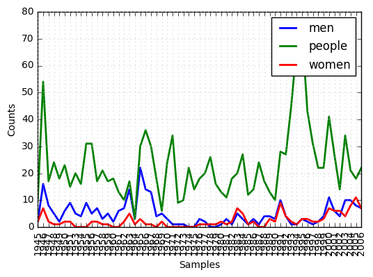

```python
cfd = nltk.ConditionalFreqDist(
    (target, fileid[:4])
    for fileid in nltk.corpus.state_union.fileids()
    for w in nltk.corpus.state_union.words(fileid)
    for target in ['men', 'women','people']
    if w.lower().startswith(target))
cfd.plot()
```

11.Investigate the table of modal distributions and look for other patterns. Try to explain them in terms of your own impressionistic understanding of the different genres. Can you find other closed classes of words that exhibit significant differences across different genres?

```python
brown.categories()
```

```
['adventure',
 'belles_lettres',
 'editorial',
 'fiction',
 'government',
 'hobbies',
 'humor',
 'learned',
 'lore',
 'mystery',
 'news',
 'religion',
 'reviews',
 'romance',
 'science_fiction']
```

```python
cfd = nltk.ConditionalFreqDist(
    (genre, word)
    for genre in brown.categories()
    for word in brown.words(categories=genre))
genres = ['news', 'religion', 'hobbies', 'science_fiction', 'romance',
          'humor','adventure','belles_lettres','editorial', 'fiction','government','learned','lore','mystery','reviews']
modals = ['can', 'could', 'may', 'might', 'must', 'will']
cfd.tabulate(conditions=genres, samples=modals)
```

```
                  can could   may might  must  will
           news    93    86    66    38    50   389
       religion    82    59    78    12    54    71
        hobbies   268    58   131    22    83   264
science_fiction    16    49     4    12     8    16
        romance    74   193    11    51    45    43
          humor    16    30     8     8     9    13
      adventure    46   151     5    58    27    50
 belles_lettres   246   213   207   113   170   236
      editorial   121    56    74    39    53   233
        fiction    37   166     8    44    55    52
     government   117    38   153    13   102   244
        learned   365   159   324   128   202   340
           lore   170   141   165    49    96   175
        mystery    42   141    13    57    30    20
        reviews    45    40    45    26    19    58
```

-Usando todos los generos, podemos ver por ejemplo que el govierno usa más will, lo sería coherente con la idea de que los gobiernos justifican sus acciones por lo que ellos consideran que estas van a lograr. -En el texto del genero de misterio la palabra que más se usa es could (podría), lo que prodia indicar que lo releante es la incertidumbre sobre cualquier evento y las posible consecuencias.

```python
cfd = nltk.ConditionalFreqDist(
    (genre, word)
    for genre in brown.categories()
    for word in brown.words(categories=genre))
genres = ['news', 'religion', 'hobbies', 'science_fiction', 'romance',
          'humor','adventure','belles_lettres','editorial', 'fiction','government','learned','lore','mystery','reviews']
modals = ['dead','love', 'pain']
cfd.tabulate(conditions=genres, samples=modals)
```

```
                dead love pain
           news    8    3    1
       religion    9   13    3
        hobbies    3    6    0
science_fiction    7    3    7
        romance   15   32    5
          humor    3    4    1
      adventure   25    9    9
 belles_lettres   20   68    4
      editorial    5   13    2
        fiction   19   16   10
     government    1    1    0
        learned   12   13   18
           lore   15   19   19
        mystery   21    7    8
        reviews    3    7    0
```

-Usando las palabras claves love, pain y dead, vemos que la palabra love es principalmente usada en belles_lettres y romance la palabra pues obviamente en estas se idealiza las relaciones con el amor. Dead es usada principalmente en mystery y aventura pues en estos textos la muerte de un individuo es muy llamativo y provoca mayor interes en el lector.